# Table of Content

- Table of Content

# 0-General

Back to Table of Content

# NutriJIA – Feasibility, Safety, and Exploratory Clinical Analysis of a Nutritional Intervention

## Introduction

Back to Table of Content

Nutritional interventions in pediatric and adolescent populations are increasingly explored as low-threshold strategies to support health and disease management. Before drawing conclusions about clinical effectiveness, it is essential to establish whether an intervention is **feasible**, **well-adhered to**, and **safe**—especially when biological safety markers and anthropometric parameters may change over time.

NutriJIA evaluates a structured nutritional intervention compared to a control condition with repeated assessments at predefined time points, most prominently:

In this notebook, feasibility is operationalised primarily through **adherence** metrics. Safety is evaluated using anthropometric and laboratory markers, including:

- weight / BMI
- Vitamin B12
- transferrin saturation
- zinc
- beta-carotene

The analyses focus on within-person change from baseline to post-intervention and on between-group differences (intervention vs. control), typically with baseline adjustment.

## Objective

Back to Table of Content

The primary goal of this analysis is **not** to maximize predictive performance, but to provide a transparent, reproducible evaluation of **feasibility and safety** and to generate **exploratory clinical signals** that can inform future confirmatory studies.

More specifically, we aim to:

1. Construct an analysis-ready participant-level dataset with:
   - group assignment (intervention vs. control)
   - adherence metrics (definition depends on available data)
   - safety endpoints (weight/BMI, Vitamin B12, transferrin saturation, zinc, beta-carotene)
   - key baseline covariates for adjustment (as pre-specified)
2. Perform the **main feasibility and safety analyses**:
   - Quantify adherence and summarise feasibility descriptively (primary).
   - Compare safety markers from baseline to post-intervention between groups using baseline-adjusted models (primary).
3. Perform **exploratory clinical analyses** (secondary):
   - Explore additional outcomes (if available) using the same baseline-adjusted framework.
   - Treat all non-safety endpoints as hypothesis-generating.
4. Integrate results into a coherent interpretation:
   - Emphasise feasibility/safety conclusions and uncertainty.
   - Clearly separate primary (feasibility/safety) from exploratory findings.

## Methodological Role

Back to Table of Content

This notebook is the central, reproducible record of:

- how raw study exports are cleaned and reshaped,
- how adherence, safety endpoints, and covariates are defined, and
- how baseline-adjusted group comparisons are implemented and reported.

## Acknowledgements

Back to Table of Content

Statistical analysis and data preparation were conducted by **Dr. Steven Ngandeu Schepanski**, who also oversaw the development of this notebook.

# Setup: Imports & Paths

Back to Table of Content

```python
import re
from pathlib import Path

import numpy as np
import pandas as pd
import matplotlib.pyplot as plt
```

# Define project paths

```python
# The user specified the intended working directory on the local machine
# On your laptop this should exist and will be used for reading and writing
# In other environments the directory may not exist, so we fall back safely
PROJECT_DIR = Path("/Users/stevenschepanski/Documents/04_ANALYSIS/NutriJIA")
```

```python
# The notebook location is documented here so that anyone reading the code
# understands where it is expected to live in the project structure
NOTEBOOK_DIR = PROJECT_DIR / "scr"
```

```python
# The data file path inside the project structure
DATA_FILE = PROJECT_DIR / "data" / "NutriJIA_SPSS_Showoff.xlsx"
```

```python
# If the project directory does not exist, fall back to the current folder
# This makes the script robust when someone runs it in a different environment
if PROJECT_DIR.exists():
    WORK_DIR = PROJECT_DIR
else:
    WORK_DIR = Path.cwd()

print("Working directory used for this run")
print(WORK_DIR)
```

```
Working directory used for this run
/Users/stevenschepanski/Documents/04_ANALYSIS/NutriJIA
```

# Pandas display preferences

```python
# These settings improve readability when inspecting intermediate tables
pd.set_option("display.max_columns", 200)
pd.set_option("display.width", 160)
```

# Read data

```python
# Read the single sheet Excel file
# If the file contains only one sheet, pandas will read it by default
# We also explicitly convert column names to strings to avoid edge cases
df_long = pd.read_excel(DATA_FILE)
df_long.columns = [str(c) for c in df_long.columns]

print("Raw long data shape")
print(df_long.shape)

print("Raw long data columns")
print(df_long.columns.tolist())
```

```
Raw long data shape
(115, 16)
Raw long data columns
['study_id', 'time', 'grp', 'kg', 'kg_percentile', 'kl', 'kl_percentile', 'bmi', 'bmi_percentile', 'globarztvas', 'globpatvas', 'tv_adhrz', 'Transferrin_Sättigung_percent', 'Zink_HP_microgramm_per_l', 'Vitamin_B12_nanogramm_per_l', 'beta_carotin_microgramm_per_l']
```

# Basic validation of the long format structure

```python
# The expected structure is one row per person per time point
# We verify that the combination of study_id and time is unique
# If it is not unique, pivoting would require aggregation which is risky
key_cols = ["study_id", "time"]

dup_mask = df_long.duplicated(subset=key_cols, keep=False)
if dup_mask.any():
    print("Warning duplicate rows detected for study_id and time")
    print(df_long.loc[dup_mask, key_cols + ["grp"]].sort_values(key_cols).head(20))
else:
    print("No duplicates detected for study_id and time")

print("Number of unique people")
print(df_long["study_id"].nunique())

print("Time point distribution")
print(df_long["time"].value_counts(dropna=False))
```

```
No duplicates detected for study_id and time
Number of unique people
23
Time point distribution
time
V0     23
V1     23
V2     23
TV1    23
TV2    23
Name: count, dtype: int64
```

# Derive a clean group variable from grp

```python
# Functin to extract group assignment from the grp column
# The grp column encodes group assignment using a pattern like
# nJIA-P-0-01  for control
# nJIA-P-1-02  for intervention
#
# There may be minor typos such as missing dashes
# We will extract the first standalone 0 or 1 after the nJIA-P marker
# If extraction fails, group will be missing and we will flag those rows

def extract_group_from_grp(value):
    """
    Extract group indicator from the grp string.

    Expected patterns include
    nJIA-P-0-01
    nJIA-P-1-02

    Also tolerates minor formatting issues such as missing a dash
    nJIA-P1-15

    Returns
    0 for control
    1 for intervention
    np.nan if parsing fails
    """
    if pd.isna(value):
        return np.nan

    s = str(value).strip()

    # First attempt
    # Look for nJIA then P then any separators then capture 0 or 1
    m = re.search(r"nJIA\s*[-_]*\s*P\s*[-_]*\s*([01])", s, flags=re.IGNORECASE)
    if m:
        return int(m.group(1))

    # Second attempt
    # A more permissive fallback that captures any 0 or 1 that is surrounded by separators
    m2 = re.search(r"(?:^|[-_])([01])(?:[-_]|$)", s)
    if m2:
        return int(m2.group(1))

    return np.nan
```

```python
# Apply the extraction function to create a new group_code column
df_long["group_code"] = df_long["grp"].apply(extract_group_from_grp)
```

```python
# Map numeric code to human readable labels
# Using explicit labels makes later tables easier to interpret
df_long["group"] = df_long["group_code"].map({0: "control", 1: "intervention"})
```

```python
# Check whether any rows failed parsing
n_missing_group = df_long["group"].isna().sum()
print("Rows with missing group after parsing")
print(n_missing_group)

if n_missing_group > 0:
    print("Examples of grp values that could not be parsed")
    print(df_long.loc[df_long["group"].isna(), ["study_id", "time", "grp"]].drop_duplicates().head(20))
```

```
Rows with missing group after parsing
0
```

```python
# Ensure each study_id has a single consistent group assignment
# If a study_id appears with both control and intervention, that is a data issue
group_by_id = (
    df_long[["study_id", "group"]]
    .drop_duplicates()
    .groupby("study_id")["group"]
    .nunique(dropna=False)
)

inconsistent_ids = group_by_id[group_by_id > 1].index.tolist()
if len(inconsistent_ids) > 0:
    print("Warning inconsistent group assignment detected for these study_id values")
    print(inconsistent_ids)
    print(df_long.loc[df_long["study_id"].isin(inconsistent_ids), ["study_id", "grp", "group"]].drop_duplicates())
else:
    print("Group assignment appears consistent within study_id")
```

```
Group assignment appears consistent within study_id
```

```python
# --- 1) Clean df_long BEFORE pivoting ---------------------------------

df_long_clean = df_long.copy()
```

```python
# Standardize time
allowed_time = {"V0", "V1", "V2", "TV1", "TV2"}
bad_time = set(df_long_clean["time"].dropna().unique()) - allowed_time
if bad_time:
    raise ValueError(f"Unexpected time values: {bad_time}")
```

```python
# Group parsing (keep your existing extraction)
df_long_clean["group_code"] = df_long_clean["grp"].apply(extract_group_from_grp)
df_long_clean["group"] = df_long_clean["group_code"].map({0: "control", 1: "intervention"})

if df_long_clean["group"].isna().any():
    raise ValueError("Some rows have missing group after parsing.")
```

```python
# Tokens interpreted as missing values across the dataset (case-insensitive handling is done below)
MISSING_TOKENS = {
    "x", "X",
    "", " ",
    "na", "n/a", "NA", "N/A",
    "nan", "NaN",
    ".", "-",
    "None", "NULL", "null",
}
```

```python
# Tokens specific to adherence columns indicating "not applicable by design"
ADHERENCE_NOT_APPLICABLE_TOKENS = {
    "Kontrolle", "kontrolle",
    "Intervention", "intervention",
}
```

```python
# Function to clean string entries in a pandas Series
def clean_string_tokens(series: pd.Series) -> pd.Series:
    """
    Standardize text-like entries and mark missing tokens as NaN.

    - strips whitespace
    - converts decimal commas to decimal points
    - converts a set of known tokens (x, NA, ., - ...) to np.nan
    - keeps other strings as-is (numeric conversion happens elsewhere)
    """
    # Keep original missing as missing
    s = series.copy()

    # Work in a string view but avoid turning true NaN into "nan" permanently
    s_str = s.astype("string").str.strip()

    # Harmonize decimal commas (German exports)
    s_str = s_str.str.replace(",", ".", regex=False)

    # Replace common missing tokens (robust to case and whitespace)
    # We compare after lowercasing
    missing_lower = {str(t).strip().lower() for t in MISSING_TOKENS}

    # Create a lowered view for comparison
    s_lower = s_str.str.lower()

    # Set missing where token matches
    s_clean = s_str.mask(s_lower.isin(missing_lower), other=pd.NA)

    # Return as object with np.nan for compatibility with numeric coercion and pandas ops
    return s_clean.astype("object").where(s_clean.notna(), np.nan)
```

```python
# Function to clean and coerce a Series to numeric
def clean_to_numeric(series: pd.Series) -> pd.Series:
    """
    Clean a Series and coerce it to numeric.
    Non-parseable entries become missing (np.nan).
    """
    s = clean_string_tokens(series)
    return pd.to_numeric(s, errors="coerce")
```

```python
# Function to clean adherence columns and coerce to numeric
def clean_adherence_to_numeric(series: pd.Series) -> pd.Series:
    """
    Clean adherence columns and coerce to numeric.

    Special handling:
    - "Kontrolle"/"Intervention" are placeholders (not adherence values) -> missing
    - remaining values coerced to numeric
    """
    s = clean_string_tokens(series)

    # Replace not-applicable placeholders (case-insensitive)
    na_tokens_lower = {t.lower() for t in ADHERENCE_NOT_APPLICABLE_TOKENS}
    s_lower = pd.Series(s, index=series.index).astype("string").str.lower()
    s = pd.Series(s, index=series.index).astype("object").mask(s_lower.isin(na_tokens_lower), other=np.nan)

    return pd.to_numeric(s, errors="coerce")
```

```python
# Identify numeric-like columns in long
id_cols_long = ["study_id", "time", "grp", "group_code", "group"]
value_cols_long = [c for c in df_long_clean.columns if c not in id_cols_long]
```

```python
# Special-case adherence
adherence_cols_long = [c for c in value_cols_long if c.lower().startswith("tv_adhrz")]

numeric_cols_long = [c for c in value_cols_long if c not in adherence_cols_long]
```

```python
# Clean numeric columns
for col in numeric_cols_long:
    df_long_clean[col] = clean_to_numeric(df_long_clean[col])
```

```python
# Clean adherence columns
for col in adherence_cols_long:
    df_long_clean[col] = clean_adherence_to_numeric(df_long_clean[col])
```

```python
# Integrity: still unique?
if df_long_clean.duplicated(subset=["study_id", "time"]).any():
    raise ValueError("Duplicate study_id+time rows exist after cleaning (unexpected).")
```

```python
# --- 2) Pivot cleaned long -> cleaned wide ----------------------------

value_cols = [c for c in df_long_clean.columns if c not in ["study_id", "group", "time", "grp", "group_code"]]

df_wide_clean = df_long_clean.pivot_table(
    index=["study_id", "group"],
    columns="time",
    values=value_cols,
    aggfunc="first"
)

df_wide_clean.columns = [f"{var}_{time}" for var, time in df_wide_clean.columns]
df_wide_clean = df_wide_clean.reset_index()
```

```python
# Integrity: one row per person
if df_wide_clean["study_id"].duplicated().any():
    raise ValueError("Wide dataset has duplicated study_id (unexpected).")
```

```python
# --- 3) Build analysis-ready one-row-per-person dataset ----------------

BASELINE_TP = "V0"
ENDPOINT_TP = "V2"

def w(var, tp):
    return f"{var}_{tp}"

core = ["study_id", "group"]
```

```python
# Put *all* outcomes you care about here (primary + safety + anthropometrics)
outcomes = [
    "globpatvas", "globarztvas",
    "bmi", "bmi_percentile",
    "kg", "kg_percentile",
    "Transferrin_Sättigung_percent",
    "Vitamin_B12_nanogramm_per_l",
    "Zink_HP_microgramm_per_l",
    "beta_carotin_microgramm_per_l",
]
```

```python
# Build columns (baseline, endpoint, and change)
cols_needed = core[:]
for v in outcomes:
    cols_needed += [w(v, BASELINE_TP), w(v, ENDPOINT_TP)]

missing = [c for c in cols_needed if c not in df_wide_clean.columns]
if missing:
    raise KeyError(f"Missing expected columns in df_wide_clean: {missing}")

df_analysis = df_wide_clean[cols_needed].copy()
```

```python
# Rename baseline/endpoint nicely + compute deltas
rename_map = {}
for v in outcomes:
    rename_map[w(v, BASELINE_TP)] = f"{v}_baseline"
    rename_map[w(v, ENDPOINT_TP)] = f"{v}_endpoint"

df_analysis = df_analysis.rename(columns=rename_map)

for v in outcomes:
    df_analysis[f"{v}_delta"] = df_analysis[f"{v}_endpoint"] - df_analysis[f"{v}_baseline"]
```

```python
# Add adherence as separate exploratory predictors (because it lives at TV1/TV2)
# Keep both, but interpret carefully because they are group-specific by design
for c in ["tv_adhrz_TV1", "tv_adhrz_TV2"]:
    if c in df_wide_clean.columns:
        df_analysis[c] = df_wide_clean[c]
```

```python
# export
out_dir = PROJECT_DIR / "data" if PROJECT_DIR.exists() else WORK_DIR

df_long_clean.to_csv(out_dir / "NutriJIA_long_clean.csv", index=False)
df_wide_clean.to_csv(out_dir / "NutriJIA_wide_clean.csv", index=False)
df_analysis.to_csv(out_dir / "NutriJIA_analysis_ready.csv", index=False)
```

# Missgness overview

```python
DATA_DIR = Path("/Users/stevenschepanski/Documents/04_ANALYSIS/NutriJIA/data")

df_wide_clean = pd.read_csv(DATA_DIR / "NutriJIA_wide_clean.csv")
df_analysis   = pd.read_csv(DATA_DIR / "NutriJIA_analysis_ready.csv")
```

```python
missing_table = (
    df_wide_clean
    .isna()
    .mean()
    .mul(100)
    .round(1)
    .reset_index()
    .rename(columns={"index": "variable", 0: "percent_missing"})
    .sort_values("percent_missing", ascending=False)
)

print(missing_table)
```

```
                            variable  percent_missing
39                      tv_adhrz_TV2             60.9
38                      tv_adhrz_TV1             56.5
13  beta_carotin_microgramm_per_l_V2             30.4
10       Zink_HP_microgramm_per_l_V2             26.1
4   Transferrin_Sättigung_percent_V2             21.7
7     Vitamin_B12_nanogramm_per_l_V2             17.4
37                  kl_percentile_V2              8.7
28                             kg_V2              8.7
22                    globarztvas_V2              8.7
31                  kg_percentile_V2              8.7
19                 bmi_percentile_V2              8.7
16                            bmi_V2              8.7
25                     globpatvas_V2              8.7
34                             kl_V2              8.7
```

[output cut: 26 more lines]

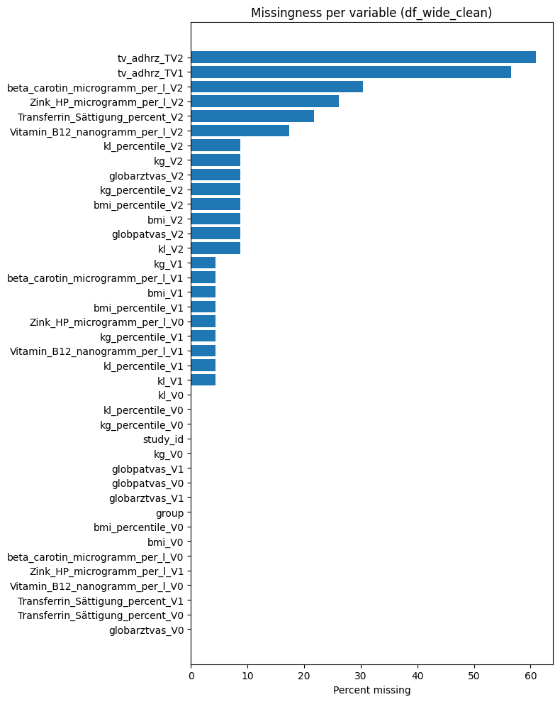

```python
plt.figure(figsize=(8, 10))
plt.barh(
    missing_table["variable"],
    missing_table["percent_missing"]
)
plt.xlabel("Percent missing")
plt.title("Missingness per variable (df_wide_clean)")
plt.gca().invert_yaxis()
plt.tight_layout()
plt.show()
```

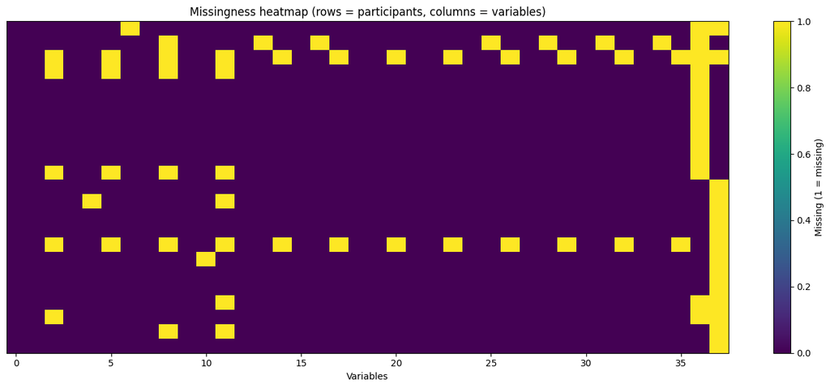

```python
# Order rows by group to make structure visible
df_plot = (
    df_wide_clean
    .sort_values("group")
    .set_index(["study_id", "group"])
)

plt.figure(figsize=(14, 6))
plt.imshow(df_plot.isna(), aspect="auto", interpolation="none")
plt.colorbar(label="Missing (1 = missing)")
plt.yticks([])
plt.xlabel("Variables")
plt.title("Missingness heatmap (rows = participants, columns = variables)")
plt.tight_layout()
plt.show()
```

```python
missing_by_group = (
    df_wide_clean
    .groupby("group")
    .apply(lambda x: x.isna().mean())
    .T
    .mul(100)
    .round(1)
)
```

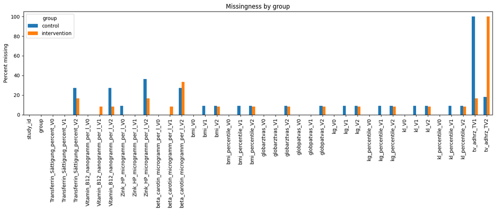

```python
missing_by_group.plot(
    kind="bar",
    figsize=(14, 6)
)
plt.ylabel("Percent missing")
plt.title("Missingness by group")
plt.xticks(rotation=90)
plt.tight_layout()
plt.show()
```

```python
analysis_missing = (
    df_analysis
    .isna()
    .mean()
    .mul(100)
    .round(1)
    .sort_values(ascending=False)
)

print(analysis_missing)
```

```
tv_adhrz_TV2                              60.9
tv_adhrz_TV1                              56.5
beta_carotin_microgramm_per_l_delta       30.4
Zink_HP_microgramm_per_l_delta            30.4
beta_carotin_microgramm_per_l_endpoint    30.4
Zink_HP_microgramm_per_l_endpoint         26.1
Transferrin_Sättigung_percent_endpoint    21.7
Transferrin_Sättigung_percent_delta       21.7
Vitamin_B12_nanogramm_per_l_delta         17.4
Vitamin_B12_nanogramm_per_l_endpoint      17.4
globpatvas_delta                           8.7
kg_delta                                   8.7
kg_percentile_endpoint                     8.7
globpatvas_endpoint                        8.7
bmi_percentile_endpoint                    8.7
globarztvas_endpoint                       8.7
kg_percentile_delta                        8.7
bmi_endpoint                               8.7
kg_endpoint                                8.7
globarztvas_delta                          8.7
bmi_delta                                  8.7
bmi_percentile_delta                       8.7
Zink_HP_microgramm_per_l_baseline          4.3
globpatvas_baseline                        0.0
globarztvas_baseline                       0.0
bmi_baseline                               0.0
kg_baseline                                0.0
beta_carotin_microgramm_per_l_baseline     0.0
bmi_percentile_baseline                    0.0
group                                      0.0
Vitamin_B12_nanogramm_per_l_baseline       0.0
Transferrin_Sättigung_percent_baseline     0.0
kg_percentile_baseline                     0.0
study_id                                   0.0
dtype: float64
```

```python
df_analysis[["globpatvas_baseline", "globpatvas_endpoint"]].notna().all(axis=1).sum()
```

```
21
```

```python
df_analysis[["globarztvas_baseline", "globarztvas_endpoint"]].notna().all(axis=1).sum()
```

```
21
```

# Longitudinal spaghetti plots (primary outcomes first)

```python
# Keep only outcome-relevant timepoints
tp_order = ["V0", "V1", "V2"]
df_long_traj = (
    df_long_clean
    .loc[df_long_clean["time"].isin(tp_order)]
    .copy()
)

df_long_traj["time"] = pd.Categorical(
    df_long_traj["time"],
    categories=tp_order,
    ordered=True
)
```

```python
df_long_traj.groupby(["group", "time"])["study_id"].nunique()
```

```
group         time
control       V0      11
              V1      11
              V2      11
intervention  V0      12
              V1      12
              V2      12
Name: study_id, dtype: int64
```

```python
# Spaghetti plot function
def spaghetti_plot(
    df,
    outcome,
    ylabel,
    title
):
    plt.figure(figsize=(6, 4))

    # Individual trajectories
    for pid, d in df.groupby("study_id"):
        plt.plot(
            d["time"],
            d[outcome],
            color="grey",
            alpha=0.4,
            linewidth=1
        )

    # Group means
    for group, d in df.groupby("group"):
        mean_traj = (
            d
            .groupby("time")[outcome]
            .mean()
        )
        plt.plot(
            mean_traj.index,
            mean_traj.values,
            linewidth=3,
            label=group
        )

    plt.xlabel("Time")
    plt.ylabel(ylabel)
    plt.title(title)
    plt.legend(title="Group")
    plt.tight_layout()
    plt.show()
```

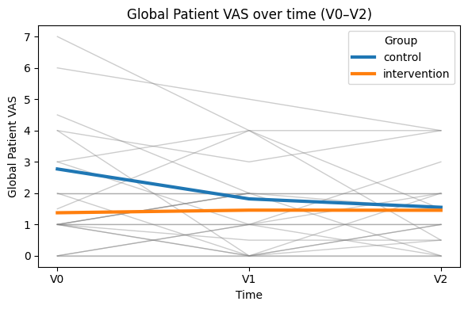

```python
spaghetti_plot(
    df=df_long_traj,
    outcome="globpatvas",
    ylabel="Global Patient VAS",
    title="Global Patient VAS over time (V0–V2)"
)
```

- Control mean trajectory trends down from V0 → V2 (roughly ~2.8 to ~1.6), i.e., improvement over time.
- Intervention mean trajectory is flat/slightly up (roughly ~1.4–1.6), i.e., little change.
- There’s substantial individual variability, and the grey lines suggest heterogeneous trajectories (some increase, some decrease), so any group difference is likely small relative to noise.
- Baseline levels differ: control looks higher at baseline, which makes baseline adjustment mandatory (ANCOVA-style).

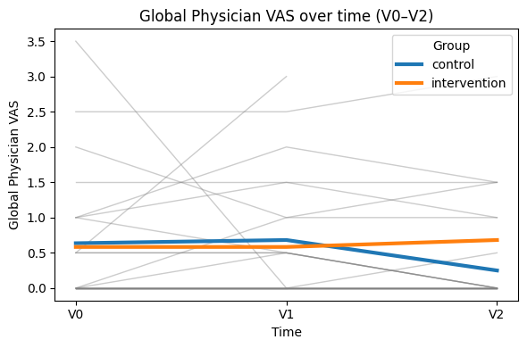

```python
spaghetti_plot(
    df=df_long_traj,
    outcome="globarztvas",
    ylabel="Global Physician VAS",
    title="Global Physician VAS over time (V0–V2)"
)
```

- Control mean trajectory trends down (improvement) by V2.
- Intervention looks flat/slightly up by V2.
- Strong floor effects (many values near 0–1), which can make linear assumptions shaky and will push us toward: a) obust summaries + effect sizes, and/or b) models tolerant of bounded/ordinal-ish outcomes (depending on scale definition).

# Visual EDA of change scores (Δ = V2 − V0) by group

```python
# Ensure expected columns exist
required = [
    "study_id", "group",
    "globpatvas_baseline", "globpatvas_endpoint",
    "globarztvas_baseline", "globarztvas_endpoint",
]
missing = [c for c in required if c not in df_analysis.columns]
if missing:
    raise KeyError(f"Missing required columns in df_analysis: {missing}")
```

```python
# Create delta dataset (explicitly)
df_delta = df_analysis[["study_id", "group"]].copy()
df_delta["globpatvas_delta"]  = df_analysis["globpatvas_endpoint"]  - df_analysis["globpatvas_baseline"]
df_delta["globarztvas_delta"] = df_analysis["globarztvas_endpoint"] - df_analysis["globarztvas_baseline"]
```

```python
# Keep baseline values for later scatter plots (baseline vs delta)
df_delta["globpatvas_baseline"]  = df_analysis["globpatvas_baseline"]
df_delta["globarztvas_baseline"] = df_analysis["globarztvas_baseline"]

print(df_delta.groupby("group")[["globpatvas_delta", "globarztvas_delta"]].agg(["count", "mean", "median", "std"]))
```

```
             globpatvas_delta                            globarztvas_delta
                        count      mean median       std             count      mean median      std
group
control                    10 -1.400000    0.0  2.525426                10 -0.400000    0.0  1.22020
intervention               11  0.045455    0.0  1.128152                11  0.045455    0.0  0.26968
```

```python
# Boxplot with dot overlay function
def delta_box_dot(df, delta_col, title, ylabel):
    groups = ["control", "intervention"]
    data = [df.loc[df["group"] == g, delta_col].dropna() for g in groups]

    plt.figure(figsize=(6, 4))
    plt.boxplot(data, labels=groups, showfliers=False)

    # dot overlay with deterministic jitter (so reruns look identical)
    for i, g in enumerate(groups, start=1):
        y = df.loc[df["group"] == g, delta_col].dropna().values
        n = len(y)
        if n == 0:
            continue
        jitter = np.linspace(-0.08, 0.08, n)  # deterministic jitter
        plt.scatter(np.full(n, i) + jitter, y)

    plt.axhline(0, linewidth=1)
    plt.title(title)
    plt.ylabel(ylabel)
    plt.tight_layout()
    plt.show()
```

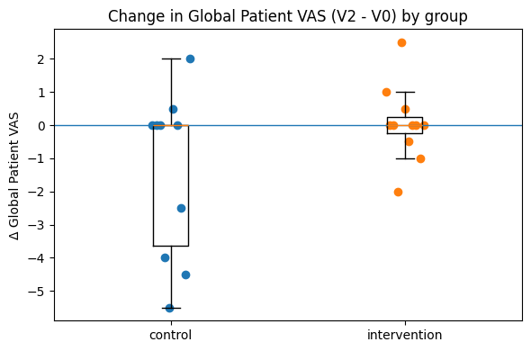

```python
delta_box_dot(
    df_delta,
    "globpatvas_delta",
    "Change in Global Patient VAS (V2 - V0) by group",
    "Δ Global Patient VAS"
)
```

**Control:**

- very wide spread of change scores
- several participants show large negative deltas, i.e. marked improvement
- median is 0, but the mean is -1.4, driven by a few strong improvers
- substantial heterogeneity: some worsen, many do not change, a few improve a lot

**Intervention:**

- changes cluster tightly around 0
- mean = 0.05, median 0
- much lower variability (SD 1.1 vs 2.5 in control)
- no clear pattern of systematic change

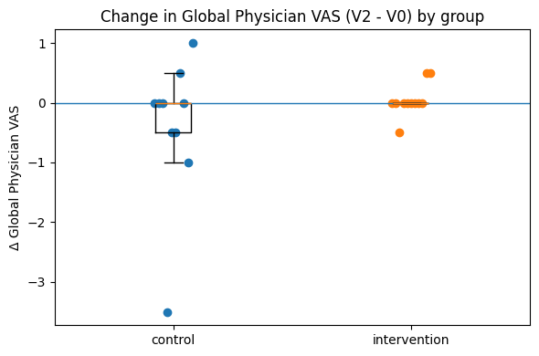

```python
delta_box_dot(
    df_delta,
    "globarztvas_delta",
    "Change in Global Physician VAS (V2 - V0) by group",
    "Δ Global Physician VAS"
)
```

**Control:**

- again, more variability than intervention
- most values around 0, but one strong negative value
- mean = -0.4, median = 0
- clear floor effect (many values at or near zero)

**Intervention:**

- almost all values exactly at 0
- very small variance
- no visible change signal

```python
# Scatter plot baseline vs delta function
def baseline_vs_delta(df, baseline_col, delta_col, title, xlabel, ylabel):
    plt.figure(figsize=(6, 4))
    for g in df["group"].dropna().unique():
        d = df[df["group"] == g].dropna(subset=[baseline_col, delta_col])
        plt.scatter(d[baseline_col], d[delta_col], label=g)

    plt.axhline(0, linewidth=1)
    plt.xlabel(xlabel)
    plt.ylabel(ylabel)
    plt.title(title)
    plt.legend(title="Group")
    plt.tight_layout()
    plt.show()
```

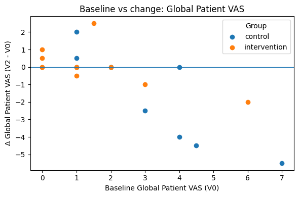

```python
baseline_vs_delta(
    df_delta,
    "globpatvas_baseline",
    "globpatvas_delta",
    "Baseline vs change: Global Patient VAS",
    "Baseline Global Patient VAS (V0)",
    "Δ Global Patient VAS (V2 - V0)"
)
```

- strong negative association between baseline severity and change:
  - participants with higher baseline VAS change more
  - participants strating near 0 cannot change
- this pattern is present in both groups but control group contains more high-baseline individuals
- intervention group has fewer high-baseline values --> limited room for change

Textbook example of "regression to the mean" + "baseline imbalance"

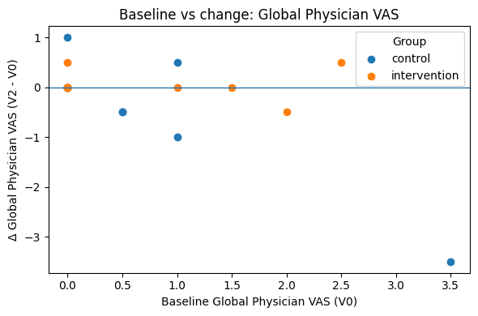

```python
baseline_vs_delta(
    df_delta,
    "globarztvas_baseline",
    "globarztvas_delta",
    "Baseline vs change: Global Physician VAS",
    "Baseline Global Physician VAS (V0)",
    "Δ Global Physician VAS (V2 - V0)"
)
```

- even stronger floor effects than patient VAS
- neagtive baseline-change association is visible

# Is there a difference between intervention vs control in Global VAS at V2, adjusting for baseline (V0)?

```python
import statsmodels.formula.api as smf

DATA_DIR = Path("/Users/stevenschepanski/Documents/04_ANALYSIS/NutriJIA/data")
df = pd.read_csv(DATA_DIR / "NutriJIA_analysis_ready.csv")
```

```python
# Keep only complete cases for the primary outcome
df_gp = (
    df[
        ["study_id", "group",
         "globpatvas_baseline", "globpatvas_endpoint"]
    ]
    .dropna()
    .copy()
)
```

```python
# Ensure group coding is explicit
df_gp["group"] = pd.Categorical(
    df_gp["group"],
    categories=["control", "intervention"]
)

print(df_gp.groupby("group").size())
```

```
group
control         10
intervention    11
dtype: int64
```

```python
model_gp = smf.ols(
    formula="globpatvas_endpoint ~ group + globpatvas_baseline",
    data=df_gp
).fit()

print(model_gp.summary())
```

```
                             OLS Regression Results
===============================================================================
Dep. Variable:     globpatvas_endpoint   R-squared:                       0.107
Model:                             OLS   Adj. R-squared:                  0.008
Method:                  Least Squares   F-statistic:                     1.083
Date:                 Tue, 16 Dec 2025   Prob (F-statistic):              0.359
Time:                         09:58:09   Log-Likelihood:                -33.968
No. Observations:                   21   AIC:                             73.94
Df Residuals:                       18   BIC:                             77.07
Df Model:                            2
Covariance Type:             nonrobust
=========================================================================================
                            coef    std err          t      P>|t|      [0.025      0.975]
-----------------------------------------------------------------------------------------
Intercept                 0.8536      0.633      1.349      0.194      -0.475       2.183
group[T.intervention]     0.2683      0.627      0.428      0.674      -1.049       1.586
globpatvas_baseline       0.2361      0.161      1.463      0.161      -0.103       0.575
==============================================================================
Omnibus:                        1.275   Durbin-Watson:                   1.720
Prob(Omnibus):                  0.529   Jarque-Bera (JB):                1.140
Skew:                           0.492   Prob(JB):                        0.565
Kurtosis:                       2.422   Cond. No.                         8.73
==============================================================================

Notes:
[1] Standard Errors assume that the covariance matrix of the errors is correctly specified.
```

```python
est = model_gp.params
ci = model_gp.conf_int()
results_gp = pd.DataFrame({
    "estimate": est,
    "ci_lower": ci[0],
    "ci_upper": ci[1],
    "p_value": model_gp.pvalues
})

print(results_gp)
```

```
                       estimate  ci_lower  ci_upper   p_value
Intercept              0.853627 -0.475463  2.182717  0.193954
group[T.intervention]  0.268290 -1.049051  1.585632  0.673818
globpatvas_baseline    0.236059 -0.103000  0.575118  0.160792
```

**globpatvas_baseline:**

- higher baseline patient-reported values tend to be associated with higher endpoint report
- direction is consistent with EDA -> regression ot the mean pattern
- uncertainty is large

**group[T.intervention]:**

- after adjusting for baseline, the intervention group has, on average, slightly higher patient VAS at V2 than control
- however: (a) confidence interval is very wide; (b) it includes substantial benefits and substantial harm; (c) estimate is small relative to residual variability

**R2 = 0.107:** Only 10.7% of variance is explained by this model

```python
df_ga = (
    df[
        ["study_id", "group",
         "globarztvas_baseline", "globarztvas_endpoint"]
    ]
    .dropna()
    .copy()
)

df_ga["group"] = pd.Categorical(
    df_ga["group"],
    categories=["control", "intervention"]
)
```

```python
model_ga = smf.ols(
    formula="globarztvas_endpoint ~ group + globarztvas_baseline",
    data=df_ga
).fit()

print(model_ga.summary())
```

```
                             OLS Regression Results
================================================================================
Dep. Variable:     globarztvas_endpoint   R-squared:                       0.376
Model:                              OLS   Adj. R-squared:                  0.307
Method:                   Least Squares   F-statistic:                     5.429
Date:                  Tue, 16 Dec 2025   Prob (F-statistic):             0.0143
Time:                          10:00:17   Log-Likelihood:                -19.997
No. Observations:                    21   AIC:                             45.99
Df Residuals:                        18   BIC:                             49.13
Df Model:                             2
Covariance Type:              nonrobust
=========================================================================================
                            coef    std err          t      P>|t|      [0.025      0.975]
-----------------------------------------------------------------------------------------
Intercept                -0.0440      0.236     -0.186      0.854      -0.540       0.452
group[T.intervention]     0.4380      0.296      1.480      0.156      -0.184       1.060
globarztvas_baseline      0.4523      0.153      2.954      0.008       0.131       0.774
==============================================================================
Omnibus:                        3.037   Durbin-Watson:                   1.681
Prob(Omnibus):                  0.219   Jarque-Bera (JB):                1.329
Skew:                           0.318   Prob(JB):                        0.515
Kurtosis:                       4.055   Cond. No.                         3.38
==============================================================================

Notes:
[1] Standard Errors assume that the covariance matrix of the errors is correctly specified.
```

```python
results_ga = pd.DataFrame({
    "estimate": model_ga.params,
    "ci_lower": model_ga.conf_int()[0],
    "ci_upper": model_ga.conf_int()[1],
    "p_value": model_ga.pvalues
})

print(results_ga)
```

```
                       estimate  ci_lower  ci_upper   p_value
Intercept             -0.044013 -0.540191  0.452164  0.854245
group[T.intervention]  0.437986 -0.183763  1.059735  0.156169
globarztvas_baseline   0.452328  0.130673  0.773983  0.008485
```

**globarztvas_baseline:**

- strong, clear association between baseline and endpoint physician ratings
- confirms what EDA suggests: (a) physician VAS is highly stable; (b) strong anchoring at baseline; (c) limited dynamic range

**group[T.intervention]:**

- direction suggests slightly higher physician VAS in the intervention group at V2
- CI crosses zero widely, effect size size is small, outcome is floor-limited
- no robust evidence

**R2 = 0.38:** High amount of variance is explained by baseline not group

# Diagnostics

```python
import statsmodels.api as sm
```

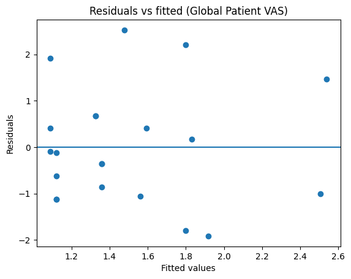

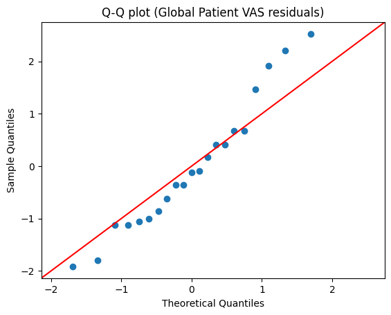

```python
# Residuals vs fitted
plt.figure()
plt.scatter(model_gp.fittedvalues, model_gp.resid)
plt.axhline(0)
plt.xlabel("Fitted values")
plt.ylabel("Residuals")
plt.title("Residuals vs fitted (Global Patient VAS)")
plt.show()

# Q-Q plot
sm.qqplot(model_gp.resid, line="45")
plt.title("Q-Q plot (Global Patient VAS residuals)")
plt.show()
```

**Residuals vs fitted:**

- residuals are roughly centered around zero, with no strong funnel shape
- no obvious nonlinear pattern
- a few points with larger residuals, but not catastrohpic outliers

**Q-Q plot:**

- residuals are approx. normal
- mild deviations in the tails, which is expected at n = 21
- nothing that invalidates OLS for exploratory inference

**Conclusion:** Model assumptions are good enough for exploratory analysis. No red flags that would force different model at this stage.

# Safety/ feasibility

```python
DATA_DIR = Path("/Users/stevenschepanski/Documents/04_ANALYSIS/NutriJIA/data")
df = pd.read_csv(DATA_DIR / "NutriJIA_analysis_ready.csv")
```

```python
anthro_vars = [
    "bmi", "bmi_percentile",
    "kg", "kg_percentile"
]

lab_vars = [
    "Vitamin_B12_nanogramm_per_l",
    "Transferrin_Sättigung_percent",
    "Zink_HP_microgramm_per_l",
    "beta_carotin_microgramm_per_l"
]
```

```python
# Summary statistics function
def describe_baseline_endpoint(df, var):
    cols = [
        f"{var}_baseline",
        f"{var}_endpoint"
    ]
    return (
        df
        .groupby("group")[cols]
        .agg(["count", "mean", "median", "std", "min", "max"])
    )
```

```python
# BMI percentile
describe_baseline_endpoint(df, "bmi_percentile")
```

| group | bmi_percentile_baseline count | bmi_percentile_baseline mean | bmi_percentile_baseline median | bmi_percentile_baseline std | bmi_percentile_baseline min | bmi_percentile_baseline max | bmi_percentile_endpoint count | bmi_percentile_endpoint mean | bmi_percentile_endpoint median | bmi_percentile_endpoint std | bmi_percentile_endpoint min | bmi_percentile_endpoint max |
| --- | --- | --- | --- | --- | --- | --- | --- | --- | --- | --- | --- | --- |
| control | 11 | 58.636364 | 57.0 | 20.568290 | 31.0 | 92.0 | 10 | 54.800000 | 51.5 | 24.484916 | 15.0 | 88.0 |
| intervention | 12 | 64.583333 | 66.5 | 32.533782 | 11.0 | 100.0 | 11 | 69.090909 | 68.0 | 27.164147 | 18.0 | 100.0 |

```python
# BMI
describe_baseline_endpoint(df, "bmi")
```

| group | bmi_baseline count | bmi_baseline mean | bmi_baseline median | bmi_baseline std | bmi_baseline min | bmi_baseline max | bmi_endpoint count | bmi_endpoint mean | bmi_endpoint median | bmi_endpoint std | bmi_endpoint min | bmi_endpoint max |
| --- | --- | --- | --- | --- | --- | --- | --- | --- | --- | --- | --- | --- |
| control | 11 | 20.427273 | 20.50 | 2.751396 | 16.9 | 26.0 | 10 | 20.320000 | 20.4 | 2.397591 | 16.2 | 24.1 |
| intervention | 12 | 23.641667 | 21.35 | 8.000166 | 14.7 | 42.9 | 11 | 24.481818 | 22.4 | 7.596423 | 17.4 | 42.2 |

```python
# Vitamin B12
describe_baseline_endpoint(df, "Vitamin_B12_nanogramm_per_l")
```

| group | Vitamin_B12_nanogramm_per_l_baseline count | Vitamin_B12_nanogramm_per_l_baseline mean | Vitamin_B12_nanogramm_per_l_baseline median | Vitamin_B12_nanogramm_per_l_baseline std | Vitamin_B12_nanogramm_per_l_baseline min | Vitamin_B12_nanogramm_per_l_baseline max | Vitamin_B12_nanogramm_per_l_endpoint count | Vitamin_B12_nanogramm_per_l_endpoint mean | Vitamin_B12_nanogramm_per_l_endpoint median | Vitamin_B12_nanogramm_per_l_endpoint std | Vitamin_B12_nanogramm_per_l_endpoint min | Vitamin_B12_nanogramm_per_l_endpoint max |
| --- | --- | --- | --- | --- | --- | --- | --- | --- | --- | --- | --- | --- |
| control | 11 | 486.909091 | 437.0 | 133.877149 | 333.0 | 695.0 | 8 | 451.500000 | 432.0 | 174.272365 | 280.0 | 744.0 |
| intervention | 12 | 449.666667 | 412.5 | 151.346882 | 294.0 | 741.0 | 11 | 463.363636 | 441.0 | 150.959115 | 281.0 | 684.0 |

```python
# Transferrin Saturation
describe_baseline_endpoint(df, "Transferrin_Sättigung_percent")
```

| group | Transferrin_Sättigung_percent_baseline count | Transferrin_Sättigung_percent_baseline mean | Transferrin_Sättigung_percent_baseline median | Transferrin_Sättigung_percent_baseline std | Transferrin_Sättigung_percent_baseline min | Transferrin_Sättigung_percent_baseline max | Transferrin_Sättigung_percent_endpoint count | Transferrin_Sättigung_percent_endpoint mean | Transferrin_Sättigung_percent_endpoint median | Transferrin_Sättigung_percent_endpoint std | Transferrin_Sättigung_percent_endpoint min | Transferrin_Sättigung_percent_endpoint max |
| --- | --- | --- | --- | --- | --- | --- | --- | --- | --- | --- | --- | --- |
| control | 11 | 25.245455 | 24.40 | 13.075807 | 8.9 | 48.5 | 8 | 20.25 | 17.20 | 12.729606 | 7.4 | 47.2 |
| intervention | 12 | 28.666667 | 25.05 | 13.690297 | 12.7 | 57.4 | 10 | 22.82 | 24.65 | 9.433722 | 8.7 | 33.5 |

```python
# Zinc
describe_baseline_endpoint(df, "Zink_HP_microgramm_per_l")
```

| group | Zink_HP_microgramm_per_l_baseline count | Zink_HP_microgramm_per_l_baseline mean | Zink_HP_microgramm_per_l_baseline median | Zink_HP_microgramm_per_l_baseline std | Zink_HP_microgramm_per_l_baseline min | Zink_HP_microgramm_per_l_baseline max | Zink_HP_microgramm_per_l_endpoint count | Zink_HP_microgramm_per_l_endpoint mean | Zink_HP_microgramm_per_l_endpoint median | Zink_HP_microgramm_per_l_endpoint std | Zink_HP_microgramm_per_l_endpoint min | Zink_HP_microgramm_per_l_endpoint max |
| --- | --- | --- | --- | --- | --- | --- | --- | --- | --- | --- | --- | --- |
| control | 10 | 685.100000 | 670.0 | 103.616226 | 502.0 | 854.0 | 7 | 577.857143 | 611.0 | 236.322117 | 81.0 | 794.0 |
| intervention | 12 | 710.083333 | 691.5 | 131.408771 | 552.0 | 933.0 | 10 | 678.000000 | 675.0 | 76.181071 | 566.0 | 766.0 |

```python
# beta Carotin
describe_baseline_endpoint(df, "beta_carotin_microgramm_per_l")
```

| group | beta_carotin_microgramm_per_l_baseline count | beta_carotin_microgramm_per_l_baseline mean | beta_carotin_microgramm_per_l_baseline median | beta_carotin_microgramm_per_l_baseline std | beta_carotin_microgramm_per_l_baseline min | beta_carotin_microgramm_per_l_baseline max | beta_carotin_microgramm_per_l_endpoint count | beta_carotin_microgramm_per_l_endpoint mean | beta_carotin_microgramm_per_l_endpoint median | beta_carotin_microgramm_per_l_endpoint std | beta_carotin_microgramm_per_l_endpoint min | beta_carotin_microgramm_per_l_endpoint max |
| --- | --- | --- | --- | --- | --- | --- | --- | --- | --- | --- | --- | --- |
| control | 11 | 454.636364 | 351.0 | 296.682751 | 97.0 | 1147.0 | 8 | 360.750 | 326.5 | 182.322908 | 68.0 | 700.0 |
| intervention | 12 | 406.750000 | 367.5 | 258.665149 | 182.0 | 1137.0 | 8 | 288.375 | 231.0 | 123.102672 | 140.0 | 451.0 |

```python
# Safety delta plot function
def safety_delta_plot(df, var, ylabel):
    delta_col = f"{var}_delta"

    plt.figure(figsize=(6, 4))

    groups = ["control", "intervention"]
    data = [
        df.loc[df["group"] == g, delta_col].dropna()
        for g in groups
    ]

    plt.boxplot(data, labels=groups, showfliers=False)

    for i, g in enumerate(groups, start=1):
        y = df.loc[df["group"] == g, delta_col].dropna().values
        n = len(y)
        if n > 0:
            jitter = np.linspace(-0.08, 0.08, n)
            plt.scatter(np.full(n, i) + jitter, y)

    plt.axhline(0)
    plt.ylabel(ylabel)
    plt.title(f"Change in {var} (V2 − V0)")
    plt.tight_layout()
    plt.show()
```

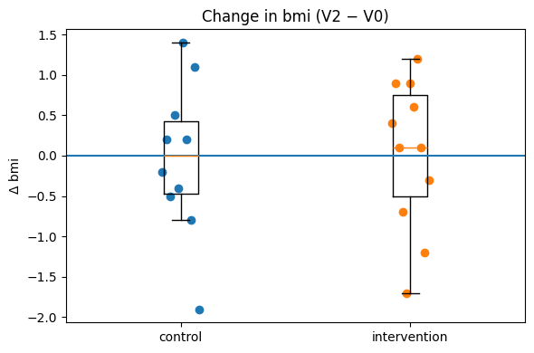

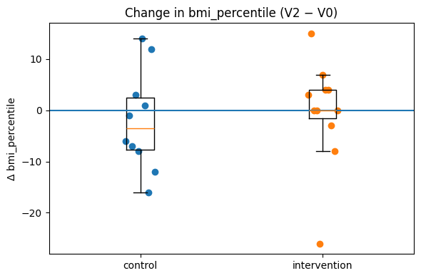

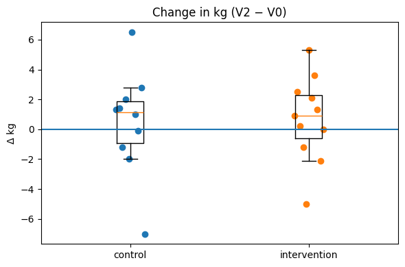

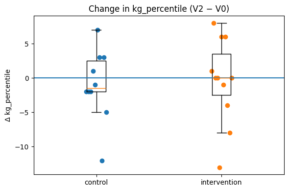

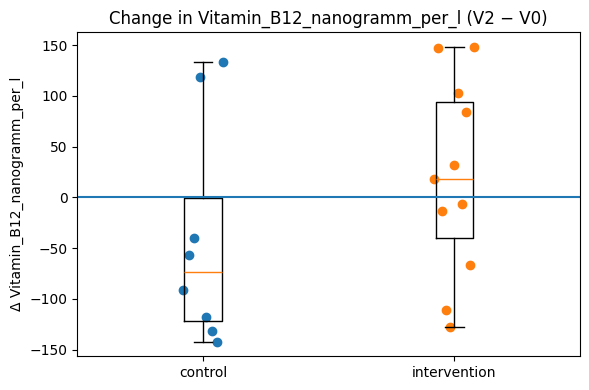

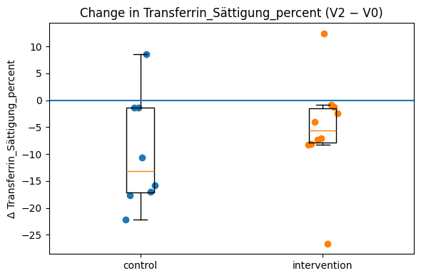

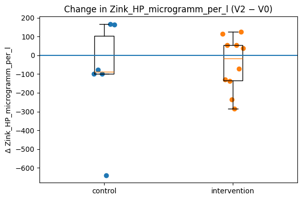

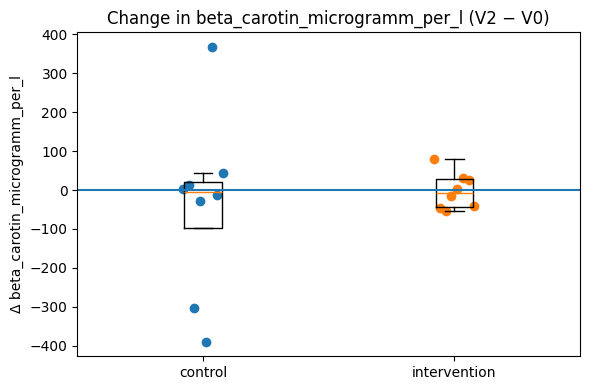

```python
for v in anthro_vars:
    safety_delta_plot(df, v, ylabel=f"Δ {v}")

for v in lab_vars:
    safety_delta_plot(df, v, ylabel=f"Δ {v}")
```

**BMI:**

- small changes centered around 0
- variability is moderate and similar in both groups

**BMI percentile:**

- wide spread in both groups
- median change are close to zero
- developmental variability not an intervention signal

**Weight and percentile:**

- systematic distribution around zero
- no consistent directionality

**vitamin B2:**

- tendey toward decline but wide spread in control and mixed changes in intervention

**transferrin:**

- both show negative deltas, meaning it declines in both groups

**zinc:**

- high variability but nothing more

**beta carotene:**

- no indicatio of intervention-related effect

```python
df_long = pd.read_csv(DATA_DIR / "NutriJIA_long_clean.csv")

df_long_safety = df_long[
    df_long["time"].isin(["V0", "V1", "V2"])
].copy()

df_long_safety["time"] = pd.Categorical(
    df_long_safety["time"],
    categories=["V0", "V1", "V2"],
    ordered=True
)
```

```python
# Spaghetti plot for safety variables
def spaghetti_safety(df, var, ylabel):
    plt.figure(figsize=(6, 4))

    for pid, d in df.groupby("study_id"):
        plt.plot(d["time"], d[var], color="grey", alpha=0.4)

    for g, d in df.groupby("group"):
        mean_traj = d.groupby("time")[var].mean()
        plt.plot(mean_traj.index, mean_traj.values, linewidth=3, label=g)

    plt.ylabel(ylabel)
    plt.title(f"{var} over time")
    plt.legend()
    plt.tight_layout()
    plt.show()
```

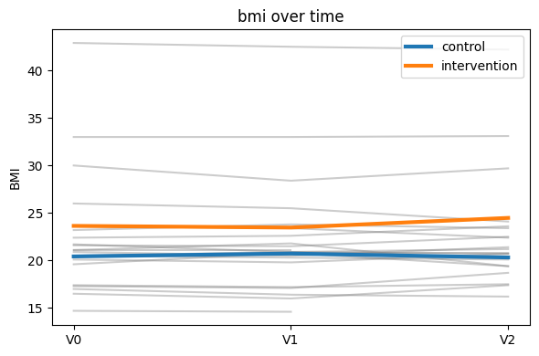

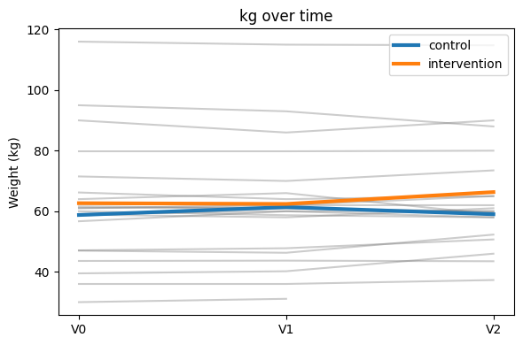

```python
spaghetti_safety(df_long_safety, "bmi", "BMI")
spaghetti_safety(df_long_safety, "kg", "Weight (kg)")
```

**BMI over time:**

- there is no signal of clinically relevant BMI instability in either group
- the slight upward trend in the intervention group is small in magnitude, consistent with normal variation, not accompanied by percentile shifts
- ==> safety interpretation: reassuring

**Weight over time:**

- weight changes are consistent with normal growth and measurement variability
- no suggestion that the intervention interferes with weight maintenance or growth
- ==> safety interpretation: reassuring

```python
safety_cols = (
    [f"{v}_baseline" for v in anthro_vars + lab_vars] +
    [f"{v}_endpoint" for v in anthro_vars + lab_vars]
)

missing_safety = (
    df[safety_cols]
    .isna()
    .mean()
    .mul(100)
    .round(1)
    .sort_values(ascending=False)
)

print(missing_safety)
```

```
beta_carotin_microgramm_per_l_endpoint    30.4
Zink_HP_microgramm_per_l_endpoint         26.1
Transferrin_Sättigung_percent_endpoint    21.7
Vitamin_B12_nanogramm_per_l_endpoint      17.4
bmi_endpoint                               8.7
bmi_percentile_endpoint                    8.7
kg_endpoint                                8.7
kg_percentile_endpoint                     8.7
Zink_HP_microgramm_per_l_baseline          4.3
bmi_baseline                               0.0
bmi_percentile_baseline                    0.0
kg_baseline                                0.0
kg_percentile_baseline                     0.0
Vitamin_B12_nanogramm_per_l_baseline       0.0
Transferrin_Sättigung_percent_baseline     0.0
beta_carotin_microgramm_per_l_baseline     0.0
dtype: float64
```

**Anthropometrics:**

- excellent completeness (less than 9% at endpoint)
- strong indicator of procedural feasibility

**Lab measures:**

==> feasbility interpretation: acceptable for a pilot

# Adherence outcomes

```python
DATA_DIR = Path("/Users/stevenschepanski/Documents/04_ANALYSIS/NutriJIA/data")
df = pd.read_csv(DATA_DIR / "NutriJIA_analysis_ready.csv")
```

```python
# Restrict to intervention group
df_int = df[df["group"] == "intervention"].copy()
```

```python
# Keep relevant columns
adherence_col = "tv_adhrz_TV1"

outcomes = [
    "globpatvas_delta",
    "globarztvas_delta",
    "bmi_delta",
    "kg_delta"
]
```

```python
# Drop rows without adherence
df_int_adhr = df_int[
    [adherence_col] + outcomes
].dropna(subset=[adherence_col])
```

```python
print("N with adherence data:", df_int_adhr.shape[0])
print(df_int_adhr[adherence_col].describe())
```

```
N with adherence data: 10
count    10.0000
mean      2.8500
std       1.6675
min       1.0000
25%       1.2500
50%       2.7500
75%       4.5000
max       5.0000
Name: tv_adhrz_TV1, dtype: float64
```

```python
# Adherence scatter plot function
def adherence_scatter(df, outcome, ylabel):
    plt.figure(figsize=(5, 4))
    plt.scatter(df[adherence_col], df[outcome])
    plt.axhline(0)
    plt.xlabel("Adherence score (TV1)")
    plt.ylabel(ylabel)
    plt.title(f"Adherence vs change in {outcome}")
    plt.tight_layout()
    plt.show()
```

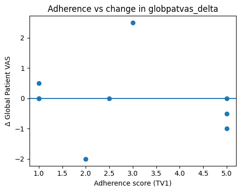

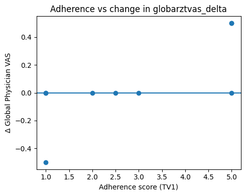

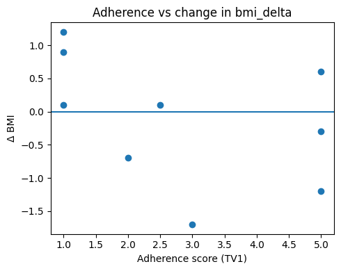

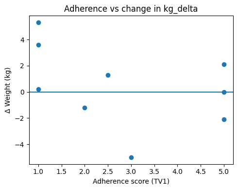

```python
adherence_scatter(df_int_adhr, "globpatvas_delta", "Δ Global Patient VAS")
adherence_scatter(df_int_adhr, "globarztvas_delta", "Δ Global Physician VAS")
adherence_scatter(df_int_adhr, "bmi_delta", "Δ BMI")
adherence_scatter(df_int_adhr, "kg_delta", "Δ Weight (kg)")
```

Across all outcomes, no consistent or monotonic association between adherence and change is evident. Variability is high, patterns are unstable, and several outcomes show minimal or near-zero variance.

```python
adherence_vars = {
    "intervention": "tv_adhrz_TV1",
    "control": "tv_adhrz_TV2"
}
```

```python
desc_tables = []

for group, var in adherence_vars.items():
    tmp = (
        df[df["group"] == group][var]
        .dropna()
        .agg(
            n="count",
            mean="mean",
            sd="std",
            median="median",
            min="min",
            max="max"
        )
        .to_frame(name=group)
    )
    desc_tables.append(tmp)

adherence_desc = pd.concat(desc_tables, axis=1)
print(adherence_desc)
```

```
        intervention   control
n            10.0000  9.000000
mean          2.8500  2.777778
sd            1.6675  1.715938
median        2.7500  3.000000
min           1.0000  0.000000
max           5.0000  5.000000
```

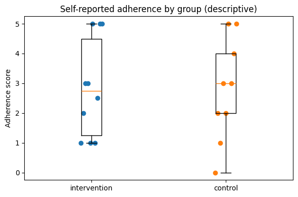

```python
plt.figure(figsize=(6, 4))

groups = []
values = []

for group, var in adherence_vars.items():
    v = df[df["group"] == group][var].dropna()
    groups.append(group)
    values.append(v)

plt.boxplot(values, labels=groups, showfliers=False)

for i, v in enumerate(values, start=1):
    jitter = np.linspace(-0.08, 0.08, len(v))
    plt.scatter(np.full(len(v), i) + jitter, v)

plt.ylabel("Adherence score")
plt.title("Self-reported adherence by group (descriptive)")
plt.tight_layout()
plt.show()
```

Self-reported adherence was assessed descriptively within each study arm during the respective intervention phases. In the intervention group, adherence scores ranged from 1 to 5 (median 2.75), indicating moderate adherence with substantial inter-individual variability. In the waitlist control group, adherence during the delayed intervention phase ranged from 0 to 5 (median 3.0), with a similar spread. Due to structural differences in timing and applicability of adherence assessments across groups, adherence measures were not directly compared and were not included in outcome models.

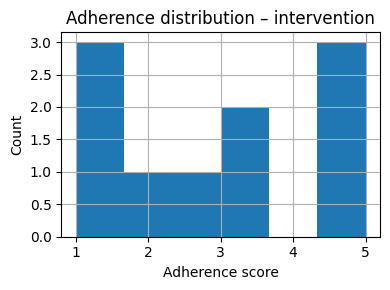

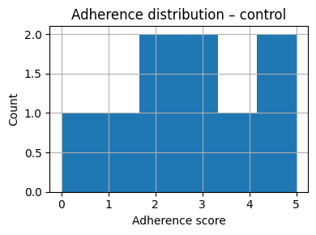

```python
for group, var in adherence_vars.items():
    plt.figure(figsize=(4, 3))
    df[df["group"] == group][var].dropna().hist(bins=6)
    plt.title(f"Adherence distribution – {group}")
    plt.xlabel("Adherence score")
    plt.ylabel("Count")
    plt.tight_layout()
    plt.show()
```